# EDA_&_MACHINE_LEARNING_Week_3

## Bedrooms count

```python
bedroom_counts = df['bedrooms'].value_counts()
bedroom_counts
```

| bedrooms | count |
| --- | --- |
| 4 | 2388 |
| 3 | 1406 |
| 5 | 869 |
| 2 | 164 |
| 6 | 114 |
| 7 | 32 |
| 8 | 8 |
| 1 | 4 |
| 9 | 3 |
| 10 | 3 |
| 36 | 3 |
| 13 | 2 |
| 11 | 2 |
| 19 | 1 |
| 18 | 1 |

**dtype:** int64

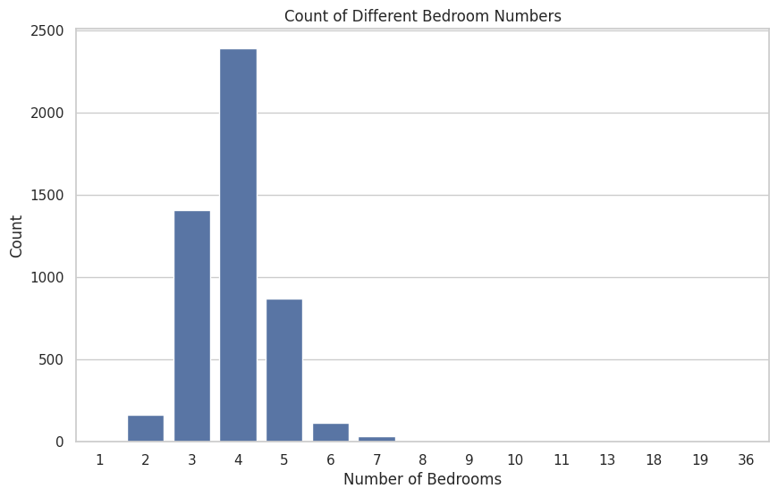

```python
# Bedrooms Bar Plot
plt.figure(figsize=(10, 6))
sns.barplot(x=bedroom_counts.index, y=bedroom_counts.values)
plt.title("Count of Different Bedroom Numbers")
plt.xlabel("Number of Bedrooms")
plt.ylabel("Count")
plt.show()
```

## Bathroom Count

```python
bathrooms_counts = df['bathrooms'].value_counts()
bathrooms_counts
```

| bathrooms | count |
| --- | --- |
| 3.0 | 1993 |
| 4.0 | 1848 |
| 5.0 | 654 |
| 6.0 | 207 |
| 2.0 | 189 |
| 7.0 | 58 |
| 8.0 | 19 |
| 9.0 | 8 |
| 3.5 | 7 |
| 2.5 | 3 |
| 1.0 | 3 |
| 35.0 | 3 |
| 11.0 | 2 |
| 10.0 | 1 |
| 4.5 | 1 |
| 14.0 | 1 |
| 18.0 | 1 |
| 15.0 | 1 |
| 36.0 | 1 |

**dtype:** int64

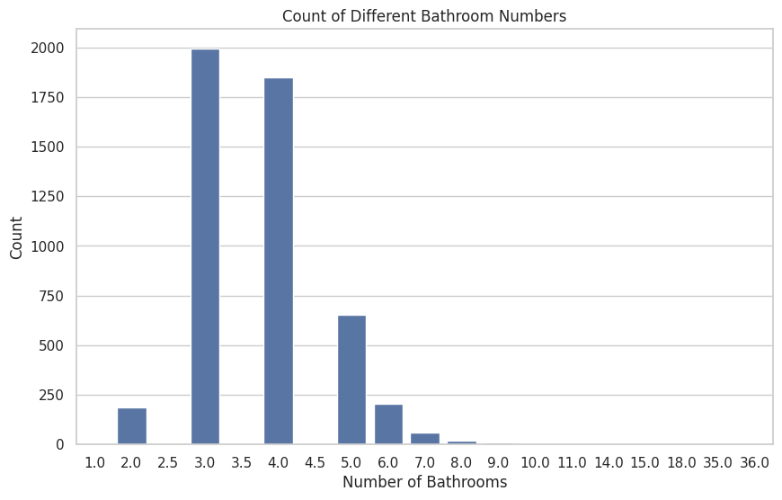

```python
# Bathroom Bar Plot
plt.figure(figsize=(10, 6))
sns.barplot(x=bathrooms_counts.index, y=bathrooms_counts.values)
plt.title("Count of Different Bathroom Numbers")
plt.xlabel("Number of Bathrooms")
plt.ylabel("Count")
plt.show()
```

## **Linear Regression Pipeline**

Once KNN has classified properties into price categories, we can set up a linear regression to predict sold_price.

- Use the output knn_price_category as an additional feature.
- Set sold_price as the target for linear regression.
- Implement a simple linear regression using gradient descent.

```python
# Create 'rooms' feature by combining bedrooms and bathrooms
df['rooms'] = df['bedrooms'] + df['bathrooms']
```

# Final Dataset for Linear Regressor Model

```python
df.head()
```

|  | MLS | sold_price | zipcode | longitude | latitude | lot_acres | taxes | year_built | bedrooms | bathrooms | sqrt_ft | garage | fireplaces | HOA | price_per_sqft | price_category | knn_price_category | rooms |
| --- | --- | --- | --- | --- | --- | --- | --- | --- | --- | --- | --- | --- | --- | --- | --- | --- | --- | --- |
| 0 | 21530491 | 5300000.0 | 85637 | -110.378200 | 31.356362 | 2154.00 | 5272.00 | 1941 | 13 | 10.0 | 10500.00000 | 0.0 | 6.0 | 0.0 | 504.761905 | 19 | 19.0 | 23.0 |
| 1 | 21529082 | 4200000.0 | 85646 | -111.045371 | 31.594213 | 1707.00 | 10422.36 | 1997 | 2 | 2.0 | 7300.00000 | 0.0 | 5.0 | 0.0 | 575.342466 | 19 | 19.0 | 4.0 |
| 2 | 3054672 | 4200000.0 | 85646 | -111.040707 | 31.594844 | 1707.00 | 10482.00 | 1997 | 2 | 3.0 | 2678.59434 | 3.0 | 5.0 | 0.0 | 1567.986588 | 19 | 4.0 | 5.0 |
| 3 | 21919321 | 4500000.0 | 85646 | -111.035925 | 31.645878 | 636.67 | 8418.58 | 1930 | 7 | 5.0 | 9019.00000 | 4.0 | 4.0 | 0.0 | 498.946668 | 19 | 19.0 | 12.0 |
| 4 | 21306357 | 3411450.0 | 85750 | -110.813768 | 32.285162 | 3.21 | 15393.00 | 1995 | 4 | 6.0 | 6396.00000 | 3.0 | 5.0 | 55.0 | 533.372420 | 19 | 19.0 | 10.0 |

# Features of the Linear Regressor

```python
# Features for the linear regressor
features = ['knn_price_category', 'sqrt_ft', 'lot_acres', 'fireplaces', 'garage', 'rooms']
X_reg = df[features].to_numpy()
y_reg = df['sold_price'].to_numpy()
```

### Scale features (standardization) using NumPy

```python
# This is important for gradient descent to work well
X_scaled = (X_reg - np.mean(X_reg, axis=0)) / np.std(X_reg, axis=0)

# Scale target variable (will help with the learning rate)
y_scaled = (y_reg - np.mean(y_reg)) / np.std(y_reg)
```

## MV Linear Regression

```
R-squared score: 0.6957
knn_price_category importance: 0.5734
sqrt_ft importance: 0.6981
lot_acres importance: 0.2534
fireplaces importance: 0.0881
garage importance: 0.0446
rooms importance: 0.1959

Mean Absolute Error: $93,790.06
```

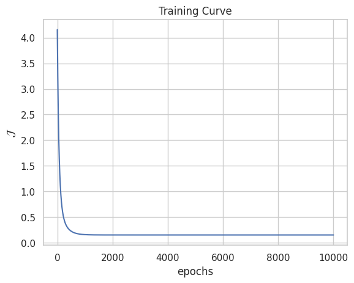

```python
# Define the OLS (Ordinary Least Squares) function
def OLS(y, y_hat, N):
    return (1/(2*N)) * np.sum((y_hat - y)**2)

class MVLinearRegression():
    def fit(self, X, y, eta=1e-3, epochs=1e3, show_curve=False):
        epochs = int(epochs)
        N, D = X.shape
        Y = y

        # Begin Optimization
        self.W = np.random.randn(D)
        self.J = np.zeros(epochs)

        # Stochastic Gradient Descent
        for epoch in range(epochs):
            Y_hat = self.predict(X)
            self.J[epoch] = OLS(Y, Y_hat, N)
            # Weight Update Rule
            self.W -= eta*(1/N)*(X.T@(Y_hat-Y))

        if show_curve:
            plt.figure()
            plt.plot(self.J)
            plt.xlabel("epochs")
            plt.ylabel("$\mathcal{J}$")
            plt.title("Training Curve")

    def predict(self, X):
        return X@self.W

# Create and train the model
my_reg = MVLinearRegression()

# Try these parameters first
my_reg.fit(X_scaled, y_scaled, eta=1e-2, epochs=1e4, show_curve=True)

# Make predictions
y_pred_scaled = my_reg.predict(X_scaled)

# Unscale predictions to get actual prices
y_pred = (y_pred_scaled * np.std(y_reg)) + np.mean(y_reg)

# Calculate R-squared
def r2_score(y_true, y_pred):
    ss_res = np.sum((y_true - y_pred) ** 2)
    ss_tot = np.sum((y_true - np.mean(y_true)) ** 2)
    return 1 - (ss_res / ss_tot)

r2 = r2_score(y_reg, y_pred)
print(f"R-squared score: {r2:.4f}")

# Print feature importance
for feature, weight in zip(features, my_reg.W):
    print(f"{feature} importance: {abs(weight):.4f}")

# Calculate Mean Absolute Error
mae = np.mean(np.abs(y_reg - y_pred))
print(f"\nMean Absolute Error: ${mae:,.2f}")
```

**R-squared score: 0.6957**

The R-squared value of 0.6957 means that approximately 69.57% of the variance in the target variable (likely property price in this context) is explained by the model. A higher R-squared generally indicates a better fit, though it depends on the domain. Here, a score of 0.6957 suggests a relatively strong fit, meaning the model is capturing the target's variability fairly well.

**Feature Importances**

These values show the relative influence of each feature in predicting the target variable. Higher values indicate more influence.

**knn_price_category importance: 0.5734**

This feature is quite influential, contributing 57.34% to the model’s predictive power. It likely represents categories based on prices of similar properties using a k-nearest neighbors (KNN) approach, which helps capture neighborhood pricing trends.

**sqrt_ft importance: 0.6981**

The square footage feature has the highest importance at 69.81%, meaning it's a critical determinant of the target variable (property price). Generally, square footage is highly correlated with property value.

**lot_acres importance: 0.25**

Lot size has a moderate importance of 25.00%, indicating that while it contributes to predicting price, it's less influential than square footage or knn_price_category.

**fireplaces importance: 0.08**

**rooms importance: 0.1959**

The total number of rooms has a moderate influence at 19.59%, suggesting that the number of rooms plays a notable role, though not as significant as square footage or neighborhood pricing trends.

# **Testing & Saving the model**

# Save Model

```python
import pickle
import numpy as np
import pandas as pd

with open('house_price_model.pkl', 'wb') as file:
    pickle.dump({
        'model': my_reg,
        'feature_means': np.mean(X_reg, axis=0),
        'feature_stds': np.std(X_reg, axis=0),
        'target_mean': np.mean(y_reg),
        'target_std': np.std(y_reg)
    }, file)


test_data = pd.DataFrame({
    'knn_price_category': [17, 8, 19],
    'lot_acres': [2.5, 1.7, 3.2],
    'sqrt_ft': [1500, 1200, 2000],
    'fireplaces': [1, 0, 2],
    'garage': [2, 1, 3],
    'rooms': [6, 4, 8]
})
```

```python
# save the model using pickle
with open('house_price_model.pkl', 'rb') as file:
    saved_model = pickle.load(file)

X_test = test_data[features].to_numpy()
X_test_scaled = (X_test - saved_model['feature_means']) / saved_model['feature_stds']
test_pred_scaled = saved_model['model'].predict(X_test_scaled)
test_predictions = (test_pred_scaled * saved_model['target_std']) + saved_model['target_mean']

# Show predictions with formatted output
print("\nPredictions for Test Data:")
print("-" * 80)
print("Test Case Details:")
for i in range(len(test_data)):
    print(f"\nHouse {i+1}:")
    print(f"Price Category: {test_data['knn_price_category'].iloc[i]}")
    print(f"Lot Acres: {test_data['lot_acres'].iloc[i]}")
    print(f"Fireplaces: {test_data['fireplaces'].iloc[i]}")
    print(f"Garage: {test_data['garage'].iloc[i]}")
    print(f"Total Rooms: {test_data['rooms'].iloc[i]}")
    print(f"Predicted Price: ${test_predictions[i]:,.2f}")
    print("-" * 40)
```

```
Predictions for Test Data:
--------------------------------------------------------------------------------
Test Case Details:

House 1:
Price Category: 17
Lot Acres: 2.5
Fireplaces: 1
Garage: 2
Total Rooms: 6
Predicted Price: $592,442.02
----------------------------------------

House 2:
Price Category: 8
Lot Acres: 1.7
Fireplaces: 0
Garage: 1
Total Rooms: 4
Predicted Price: $265,555.66
----------------------------------------

House 3:
Price Category: 19
Lot Acres: 3.2
Fireplaces: 2
Garage: 3
Total Rooms: 8
Predicted Price: $737,768.16
----------------------------------------
```

# Manual Verification

```python
# Manual verification
indices = [470]
actual_prices_subset = y_reg[indices]
predicted_prices_subset = y_pred[indices]

# Calculate absolute errors for the subset
absolute_errors = np.abs(actual_prices_subset - predicted_prices_subset)

# Calculate manual MAE for the subset
manual_mae = np.mean(absolute_errors)

# Print out the values for comparison
print("Manual MAE Calculation for Selected Houses:")
for i in indices:
    print(f"House {i + 1}:")
    print(f"Actual Price: ${y_reg[i]:,.2f}")
    print(f"Predicted Price: ${y_pred[i]:,.2f}")
    print(f"Absolute Error: ${absolute_errors[indices.index(i)]:,.2f}")
    print("-" * 40)

print(f"\nManual Mean Absolute Error: ${manual_mae:,.2f}")
```

```
Manual MAE Calculation for Selected Houses:
House 471:
Actual Price: $1,065,000.00
Predicted Price: $1,048,703.07
Absolute Error: $16,296.93
----------------------------------------

Manual Mean Absolute Error: $16,296.93
```

# Predicting the results using Test data

```python
test_df = pd.read_csv("test_data.csv")
features = ['knn_price_category', 'sqrt_ft', 'lot_acres', 'fireplaces', 'garage', 'rooms']
X_test = test_data[features].to_numpy()
y_test_pred_scaled = my_reg.predict(X_test_scaled)
y_test_pred = (y_test_pred_scaled * np.std(y_reg)) + np.mean(y_reg)
test_data['predicted_sold_price'] = y_test_pred
```

```python
#Print the predicted prices
print("Predicted Sold Prices:")
print(test_data[['predicted_sold_price']])
```

```
Predicted Sold Prices:
   predicted_sold_price
0         592442.018419
1         265555.657397
2         737768.162413
```